# Segmentation of EU countries, based on consumer & business indicators

The eurozone consists of 19 countries: Austria, Belgium, Cyprus, Estonia, Finland, France, Germany, Greece, Ireland, Italy, Latvia, Lithuania, Luxembourg, Malta, the Netherlands, Portugal, Slovakia, Slovenia, and Spain.

The [Eurostat package](https://cran.r-project.org/web/packages/eurostat/index.html) used to obtain the original datasets.

# Exploratory Analysis

It would be interesting to see the map plots of the confidence indicators. At first below there is a plot with the aggreagated business indicator

[output not shown]

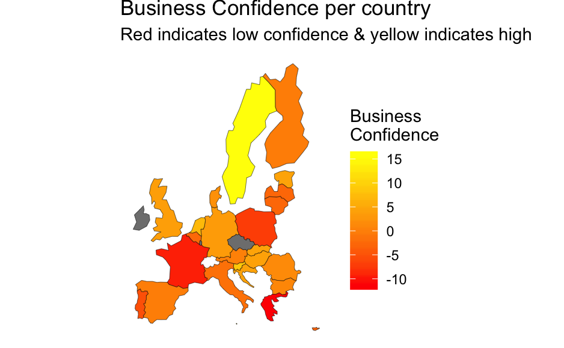

```r
# Create table
europeanUnionTable <- data.frame(country = final$geo, value = final$Business)
europeCoords$value <- europeanUnionTable$value[match(europeCoords$region,europeanUnionTable$country)]
# Plot the map
ggplot() +
  geom_polygon(data = europeCoords, aes(x = long, y = lat, group = region, fill = value),
                             colour = "black", size = 0.1) +
  coord_map(xlim = c(-13, 35),  ylim = c(32, 71)) +
  scale_fill_gradient(name = "Business Confidence Indicator", low = "#FF0000FF", high = "#FFFF00FF", na.value = "grey50") +
  theme(axis.text.x = element_blank(),
  axis.text.y = element_blank(), axis.ticks.x = element_blank(),
  axis.ticks.y = element_blank(), axis.title = element_blank(),
  plot.margin = unit(0 * c(-1.5, -1.5, -1.5, -1.5), "lines")) +
  scale_fill_gradient(name = "Business \nConfidence", low = "#FF0000FF", high = "#FFFF00FF", na.value = "grey50") +
  labs(title = "Business Confidence per country",
       subtitle = "Red indicates low confidence & yellow indicates high")+
  theme(panel.grid = element_blank(),
        axis.text = element_blank(),
        axis.ticks = element_blank(),
        panel.background = element_blank())
```

- It is clear that there are a few differences between countries.
- In general Nothern Europe countries tend to have higher business confidence indicators.

Below there is a plot with the confidence indicator per EU country

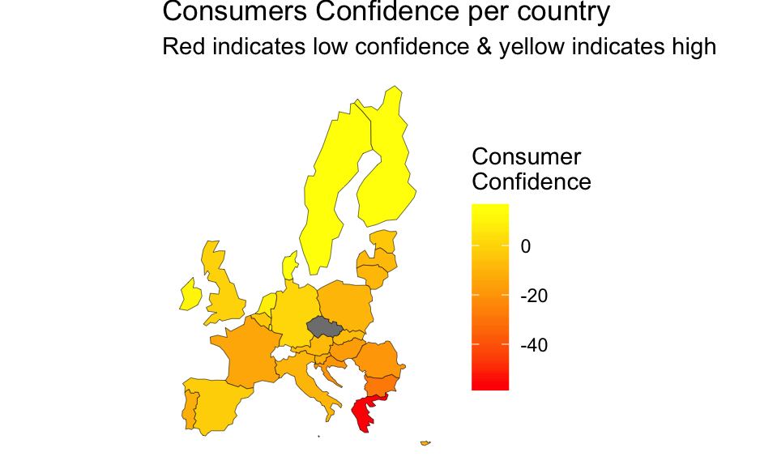

- Again, Nothern Europe countries tend to have higher consumers confidence indicators.
- It seems that there are outlies here. Greece has significantly lower confidence indicator than the rest of the countries.

Below there is a scatterplot with marker labels indicating the positioning of each country in respect to consumer and confidence indicators. The overall business confidence indicator is the average of all business related features (Construction confidence indicator, Industrial confidence indicator, Retail confidence indicator & Services Confidence Indicator)

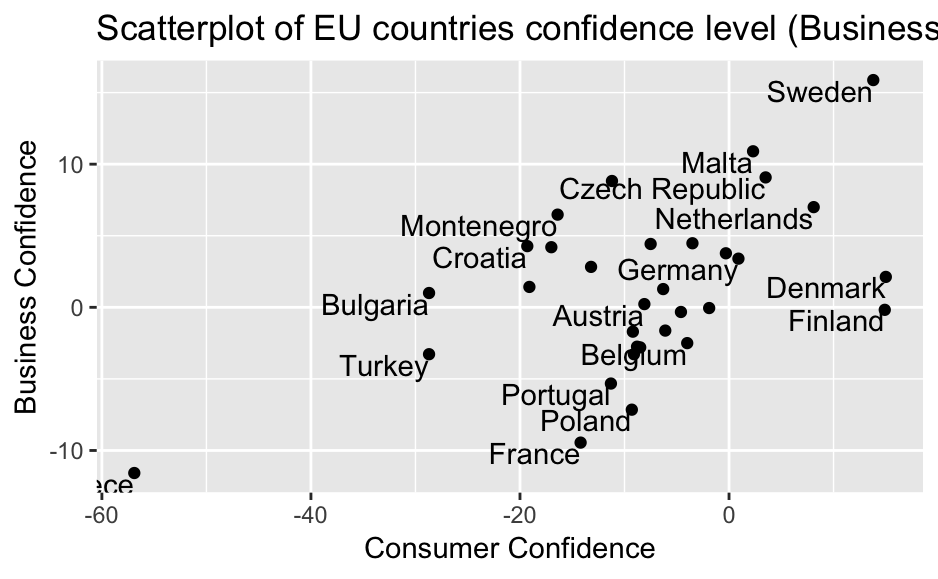

# Modelling-Clustering

There are quite a few differences between countries regarding confidence indicators. It would be very interesting to develop a segmentation, in order to check how well the countries are forming teams.

## K-means Check optimal number of k with elbow (scree) plot

The scree plot below, can be used to check for the suitable number of clusters.

In detail, the total within cluster sum of squares is calculated (the sum of euclidean distances between each observation and the centroid corresponding to the cluster to which the observation is assigned).

So what we are looking for is the point at which the curve begins to flatten out.

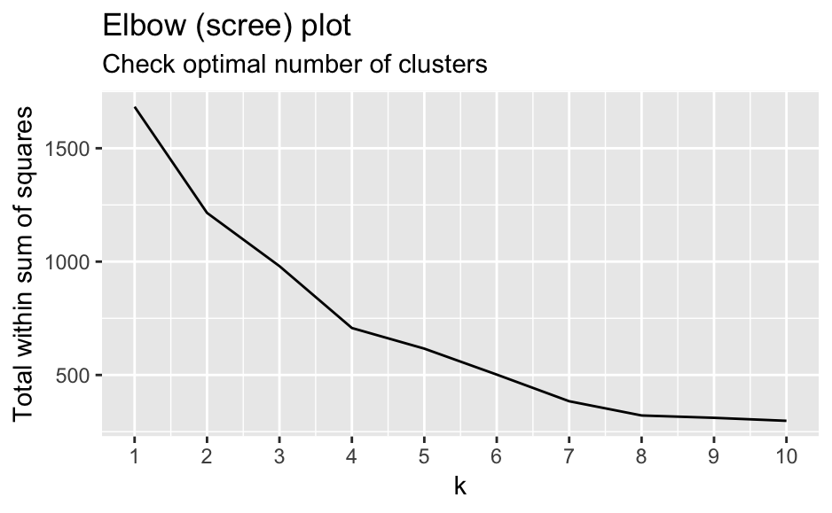

## K-means (All variables) silhouette analysis

In general, silhouette analysis determines how well each of the observations fit into corresponding cluster (Higher is better).

It involves calculating a measurement called the silhouette width for every observation which consists of 2 parts i) the within cluster distance C (average distance from that observation to every other observation within the cluster) and ii) the closest neighbor distance N (the average distance from that observation to the points of the closest neighboring cluster).  
Calculation:  
- if C < N then 1 - C/N  
- if C = N then 0  
- if C > N then N/C - 1

Interpretation: - A value close to 1 suggests that this observation is well matched to its current cluster.  
- A value of 0 suggests that it is on the border between two clusters and can possibly belong to either one.  
- A value close to -1 suggests that the observation has a better fit to its closest neighboring cluster.

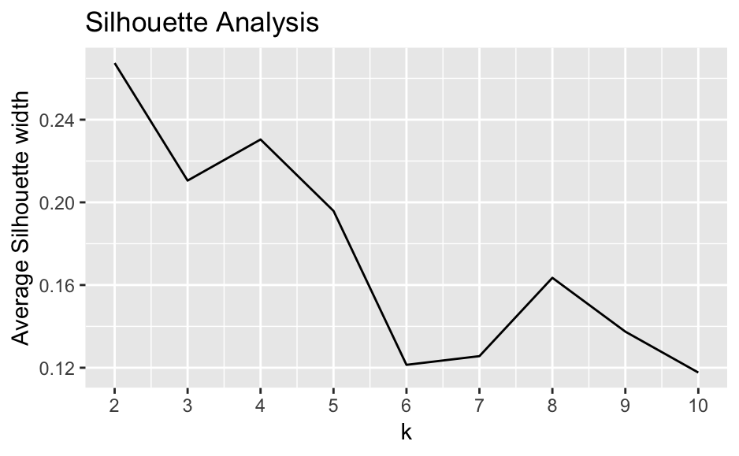

Although the silhouette value of the two clusters is the highest, four clusters were chosen for a few reasons:  
- It is close to the highest value  
- From the elbow plot, it seems that the curve is flatten out after cluster 4  
- Two clusters are very few to represent differences in EU countries

## PCA Biplot

It is a dimensionality reduction technique, which find structure in features and Aid in visualization.  
- It will find linear combination of variables to create principal components (new features)  
- Maintain most variance in the data  
- Principal components (new features) are uncorrelated (i.e. orthogonal to each other)

This plot shows all the original observations plotted on the first 2 principal components. It also shows the original features mapped as vectors.

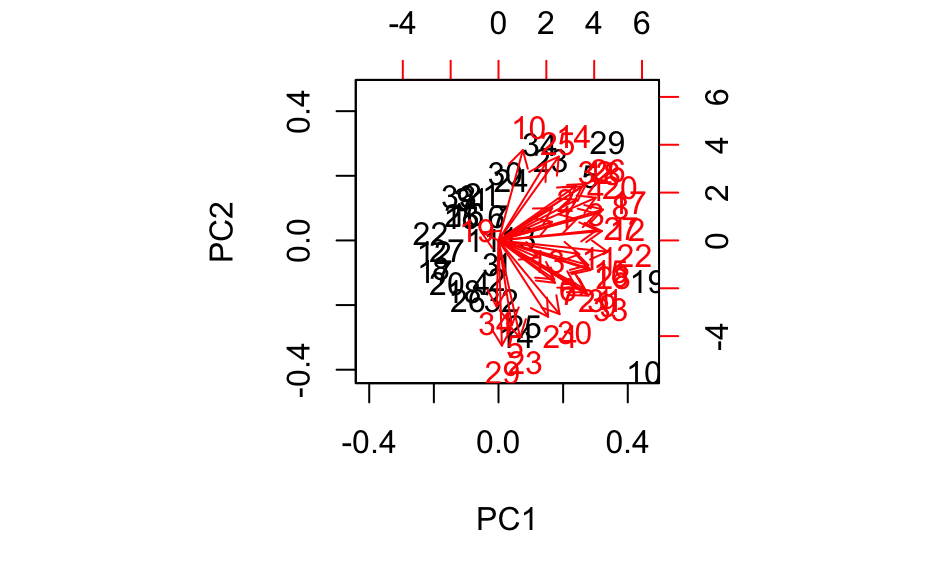

```r
pca_soft <- prcomp(scale(kmeans.dat))
# # Create a vector with clusters
# clusters <- factor(model_customers$cluster)
# levels(clusters) <- c("B", "D", "A", "E", "C")
# simple Biplot
biplot(pca_soft)
```

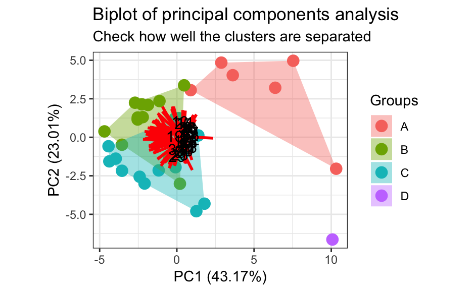

```r
library(ggord)
ggord(pca_soft, segment_countries$cluster, ellipse = FALSE, hull = TRUE, arrow = 1, vec_ext = 3, veccol = 'red', veclsz = 1) +
  labs(title = "Biplot of principal components analysis",
       subtitle = "Check how well the clusters are separated",
       col = "Clusters")
```

## Map countries with cluster

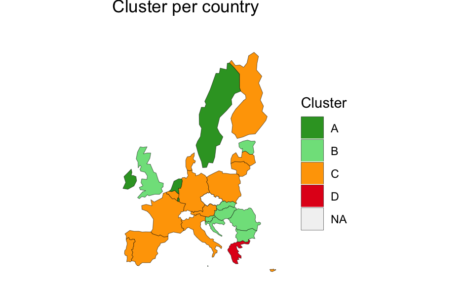

```r
# Create table with results
europeanUnionTable <- data.frame(country = segment_countries$geo, value = factor(segment_countries$cluster))
europeCoords$value <- europeanUnionTable$value[match(europeCoords$region,europeanUnionTable$country)]
# Plot the map
ggplot() +
  geom_polygon(data = europeCoords, aes(x = long, y = lat, group = region, fill = value),
                             colour = "black", size = 0.1) +
  coord_map(xlim = c(-13, 35),  ylim = c(32, 71))+
  theme(
  axis.text.x = element_blank(),
  axis.text.y = element_blank(), axis.ticks.x = element_blank(),
  axis.ticks.y = element_blank(), axis.title = element_blank(),
  plot.margin = unit(0 * c(-1.5, -1.5, -1.5, -1.5), "lines")) +
  labs(title = "Cluster per country",
       subtitle = "",
       fill = "Cluster")+
  theme(panel.grid = element_blank(),
        axis.text = element_blank(),
        axis.ticks = element_blank(),
        panel.background = element_blank()) +
   scale_fill_manual(values=c("#33A02C", "#7EE08B", "#FFA500", "#E31A1C"))
```

# SCRAP WORK

```r
knitr::knit_exit()
```

## Hierarchical clustering

The first methodology i used, was hierarchical clustering.